# Replication of ‘Migration and Innovation: Learning from Patent and Inventor Data’

Manvanth Sundareshan- 400353080

## Introduction

The article “Migration and Innovation: Learning from Patent and Inventor Data” by Francesco Lissoni and Ernest Miguelez, published in the *Journal of Economic Perspectives*, investigates the crucial contributions of migrant inventors to technological innovation (Lissoni and Miguelez 2024).

By analyzing data on patents and inventors, the authors reveal both historical and current examples of how migration fuels innovation, such as Katalin Karikó’s work on mRNA technology (Lissoni and Miguelez 2024). The study finds that migrant inventors are highly productive, frequently appear in patent records, and play a key role in addressing R&D labor shortages and enhancing diversity in scientific fields (Lissoni and Miguelez 2024).

The paper uses various approaches to identify migrant inventors, including cross-country mobility analysis, name-based ethnicity analysis, and linking patent data with other administrative records (Lissoni and Miguelez 2024).

Despite limitations in the data, the research highlights the significant role of migrant inventors in knowledge dissemination and calls for improved data integration in future studies to fully capture their impact on global technological advancement (Lissoni and Miguelez 2024).

## Source of the data

Replication package of Lissoni and Miguelez (2024)

## Size and structure of the dataset used for Figure 1

This data set has 20778686 observations of 6 variables.

In table it has patent_id, Investor_id, country, year, wipo_sector_title and wipo_field_title.

## Why this dataset is suitable for generating figure 1?

The dataset, containing patent_id, investor_id, country, year, wipo_sector_title, and wipo_field_title, is suitable for research on innovation and migration due to its detailed tracking of patent activities and inventor demographics across different countries and sectors.

## Code to replication of graph in figure 1

```r
# Install tidyverse if required
if (!require(tidyverse)) {
  install.packages("tidyverse")
  library(tidyverse)
} else {
  library(tidyverse)
}
# Install haven if required
if (!require(haven)) {
  install.packages("haven")
  library(haven)
} else {
  library(haven)
}
```

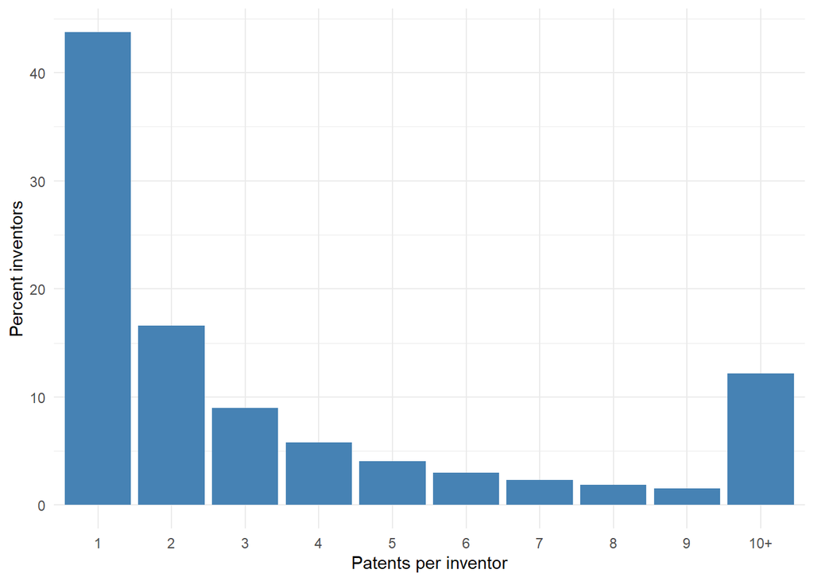

```r
# Install dplyr if required
if (!require(dplyr)) {
  install.packages("dplyr")
  library(dplyr)
} else {
  library(dplyr)
}

# Define the file path to the uploaded file
file_path <- "D:/Hochschule Fresenius notes (sem2)/SS 2024- Data Science in business/Final_Project/Data/Created-data/uspto_inventors_coords.dta"

# Read the .dta file
uspto_inventors_coords <- read_dta(file_path)
View(uspto_inventors_coords)

# Count the number of patents per inventor
inventor_patents <- uspto_inventors_coords |>
  group_by(inventor_id) |>
  summarise(patent_count = n())

# Create a new data frame with the percentage of inventors per patent count
patent_distribution <- inventor_patents |>
  count(patent_count) |>
  mutate(percent_inventors = n / sum(n) * 100)

# Bin the patent counts as shown in the example plot
patent_distribution <- patent_distribution |>
  mutate(patent_count = ifelse(patent_count >= 10, "10+", as.character(patent_count)),
         patent_count = factor(patent_count, levels = c(as.character(1:9), "10+")))

# Plot the data
ggplot(patent_distribution, aes(x = patent_count, y = percent_inventors)) +
  geom_bar(stat = "identity", fill = "steelblue") +
  labs(x = "Patents per inventor", y = "Percent inventors") +
  theme_minimal()
```

## Challenges faced

During the process of executing a `git push` to update my GitHub repository, I encountered an issue related to generating the HTML file through the repository. In the current repository, accessible at https://github.com/codeflex98/codeflex98.github.io, a file named `DS_Report.HTML` was added.

This file can be accessed via the URL `codeflex98.github.io/DS_Report.HTML`. However, for proper execution, the forward slash in the URL must be replaced with a backslash, resulting in the following format: `codeflex98.github.io\DS_Report.HTML`.

## References

Lissoni, Francesco, and Ernest Miguelez. 2024. “Migration and Innovation: Learning from Patent and Inventor Data.” *Journal of Economic Perspectives* 38 (1): 27–54. https://doi.org/10.1257/jep.38.1.27.